# Cybersecurity Threats Analysis (2015-2024)

This project analyzes global cybersecurity threats data from 2015 to 2024, examining attack patterns, financial impacts, and defense mechanisms across countries and industries.

```python
import mysql.connector

# Replace these values with your MySQL server information
host = 'localhost'  # e.g., 'localhost'
database = 'cybersecurity'
user = 'root'
password = 'N0Passw0rd'

# Establishing the connection
connection = mysql.connector.connect(
    host=host,
    database=database,
    user=user,
    password=password
)

# Check if the connection is successful
if connection.is_connected():
    print("Connection established successfully!")
else:
    print("Failed to connect to the database.")
```

```
Connection established successfully!
```

```python
# Create a cursor object to interact with the database
cursor = connection.cursor()

# SQL query to retrieve data from a table
query = "SELECT * FROM global_cybersecurity_threats"
cursor.execute(query)

# Fetch all results into a pandas DataFrame
columns = [desc[0] for desc in cursor.description]  # Get column names
data = cursor.fetchall()
```

Import Libries

```python
import pandas as pd
import numpy as np
import matplotlib.pyplot as plt
import seaborn as sns
from matplotlib.ticker import FuncFormatter

# Set style for visualizations
sns.set(style="ticks")
sns.set_palette("husl")
```

```python
# Convert the data into a Pandas DataFrame
df = pd.DataFrame(data, columns=columns)
```

## Display basic info

```python
df.shape
```

```
(3000, 10)
```

```python
# Check for missing values
print(df.isnull().sum())
```

```
Country                                0
Year                                   0
Attack Type                            0
Target Industry                        0
Financial Loss (in Million $)          0
Number of Affected Users               0
Attack Source                          0
Security Vulnerability Type            0
Defense Mechanism Used                 0
Incident Resolution Time (in Hours)    0
dtype: int64
```

```python
df.info()
```

```
<class 'pandas.core.frame.DataFrame'>
RangeIndex: 3000 entries, 0 to 2999
Data columns (total 10 columns):
 #   Column                               Non-Null Count  Dtype
---  ------                               --------------  -----
 0   Country                              3000 non-null   object
 1   Year                                 3000 non-null   int64
 2   Attack Type                          3000 non-null   object
 3   Target Industry                      3000 non-null   object
 4   Financial Loss (in Million $)        3000 non-null   int64
 5   Number of Affected Users             3000 non-null   int64
 6   Attack Source                        3000 non-null   object
 7   Security Vulnerability Type          3000 non-null   object
 8   Defense Mechanism Used               3000 non-null   object
 9   Incident Resolution Time (in Hours)  3000 non-null   int64
dtypes: int64(4), object(6)
memory usage: 234.5+ KB
```

```python
# Convert Financial loss (in Million $) to float in 2 decimal places
df['Financial Loss (in Million $)'] = df['Financial Loss (in Million $)'].astype(float).round(2)
df.info()
```

```
<class 'pandas.core.frame.DataFrame'>
RangeIndex: 3000 entries, 0 to 2999
Data columns (total 10 columns):
 #   Column                               Non-Null Count  Dtype
---  ------                               --------------  -----
 0   Country                              3000 non-null   object
 1   Year                                 3000 non-null   int64
 2   Attack Type                          3000 non-null   object
 3   Target Industry                      3000 non-null   object
 4   Financial Loss (in Million $)        3000 non-null   float64
 5   Number of Affected Users             3000 non-null   int64
 6   Attack Source                        3000 non-null   object
 7   Security Vulnerability Type          3000 non-null   object
 8   Defense Mechanism Used               3000 non-null   object
 9   Incident Resolution Time (in Hours)  3000 non-null   int64
dtypes: float64(1), int64(3), object(6)
memory usage: 234.5+ KB
```

```python
# Basic statistics for numerical columns
print(df.describe())
```

```
              Year  Financial Loss (in Million $)  Number of Affected Users  \
count  3000.000000                    3000.000000               3000.000000
mean   2019.570333                      50.503333             504684.136333
std       2.857932                      28.787351             289944.084972
min    2015.000000                       1.000000                424.000000
25%    2017.000000                      26.000000             255805.250000
50%    2020.000000                      51.000000             504513.000000
75%    2022.000000                      76.000000             758088.500000
max    2024.000000                     100.000000             999635.000000

       Incident Resolution Time (in Hours)
count                          3000.000000
mean                             36.476000
std                              20.570768
min                               1.000000
25%                              19.000000
50%                              37.000000
75%                              55.000000
max                              72.000000
```

## Data Distribution by Year

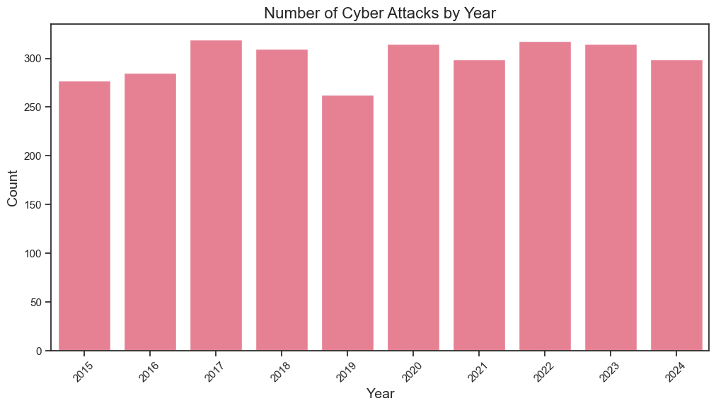

```python
# Attacks by year
plt.figure(figsize=(12, 6))
sns.countplot(x='Year', data=df, order=sorted(df['Year'].unique()))
plt.title('Number of Cyber Attacks by Year', fontsize=16)
plt.xlabel('Year', fontsize=14)
plt.ylabel('Count', fontsize=14)
plt.xticks(rotation=45)
plt.show()
```

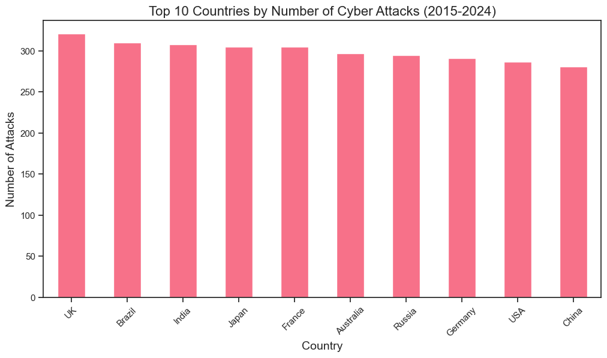

```python
# Top 10 countries by number of attacks
country_counts = df['Country'].value_counts().head(10)
plt.figure(figsize=(12, 6))
country_counts.plot(kind='bar')
plt.title('Top 10 Countries by Number of Cyber Attacks (2015-2024)', fontsize=16)
plt.xlabel('Country', fontsize=14)
plt.ylabel('Number of Attacks', fontsize=14)
plt.xticks(rotation=45)
plt.show()
```

## Attack Type Analysis

Most Common Attack Types

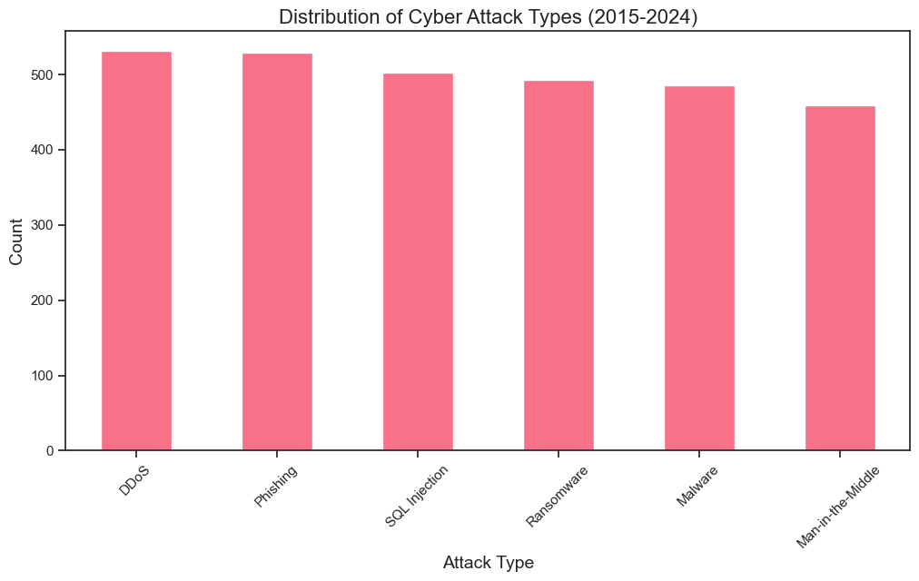

```python
# Attack type distribution
plt.figure(figsize=(12, 6))
attack_counts = df['Attack Type'].value_counts()
attack_counts.plot(kind='bar')
plt.title('Distribution of Cyber Attack Types (2015-2024)', fontsize=16)
plt.xlabel('Attack Type', fontsize=14)
plt.ylabel('Count', fontsize=14)
plt.xticks(rotation=45)
plt.show()
```

Attack Types Over Time

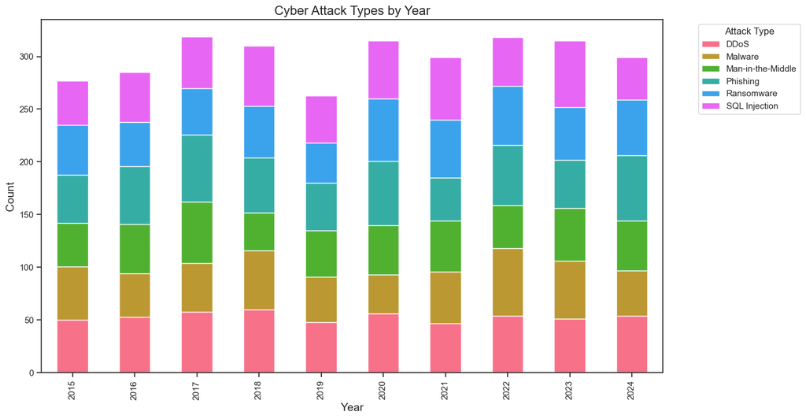

```python
# Attack types by year
plt.figure(figsize=(14, 8))
attack_year = pd.crosstab(df['Year'], df['Attack Type'])
attack_year.plot(kind='bar', stacked=True, figsize=(14, 8))
plt.title('Cyber Attack Types by Year', fontsize=16)
plt.xlabel('Year', fontsize=14)
plt.ylabel('Count', fontsize=14)
plt.legend(title='Attack Type', bbox_to_anchor=(1.05, 1), loc='upper left')
plt.show()
```

## Financial Impact Analysis

Total Financial Loss by Country

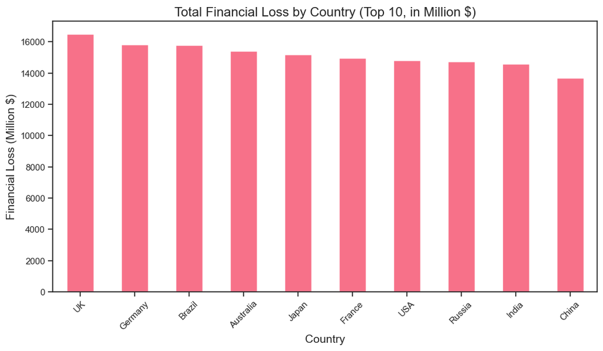

```python
# Financial loss by country (top 10)
financial_loss = df.groupby('Country')['Financial Loss (in Million $)'].sum().sort_values(ascending=False).head(10)
plt.figure(figsize=(12, 6))
financial_loss.plot(kind='bar')
plt.title('Total Financial Loss by Country (Top 10, in Million $)', fontsize=16)
plt.xlabel('Country', fontsize=14)
plt.ylabel('Financial Loss (Million $)', fontsize=14)
plt.xticks(rotation=45)
plt.show()
```

Financial Loss by Attack Type

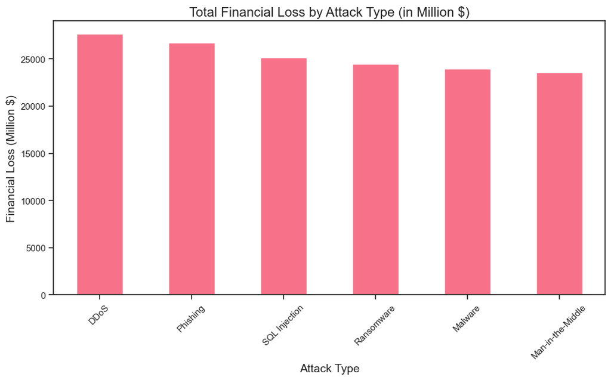

```python
# Financial loss by attack type
loss_by_attack = df.groupby('Attack Type')['Financial Loss (in Million $)'].sum().sort_values(ascending=False)
plt.figure(figsize=(12, 6))
loss_by_attack.plot(kind='bar')
plt.title('Total Financial Loss by Attack Type (in Million $)', fontsize=16)
plt.xlabel('Attack Type', fontsize=14)
plt.ylabel('Financial Loss (Million $)', fontsize=14)
plt.xticks(rotation=45)
plt.show()
```

## Target Industry Analysis

Most Targeted Industries

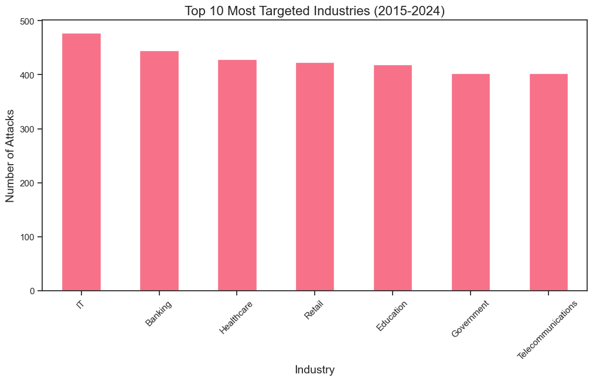

```python
# Most targeted industries
plt.figure(figsize=(12, 6))
industry_counts = df['Target Industry'].value_counts().head(10)
industry_counts.plot(kind='bar')
plt.title('Top 10 Most Targeted Industries (2015-2024)', fontsize=16)
plt.xlabel('Industry', fontsize=14)
plt.ylabel('Number of Attacks', fontsize=14)
plt.xticks(rotation=45)
plt.show()
```

Financial Loss by Industry

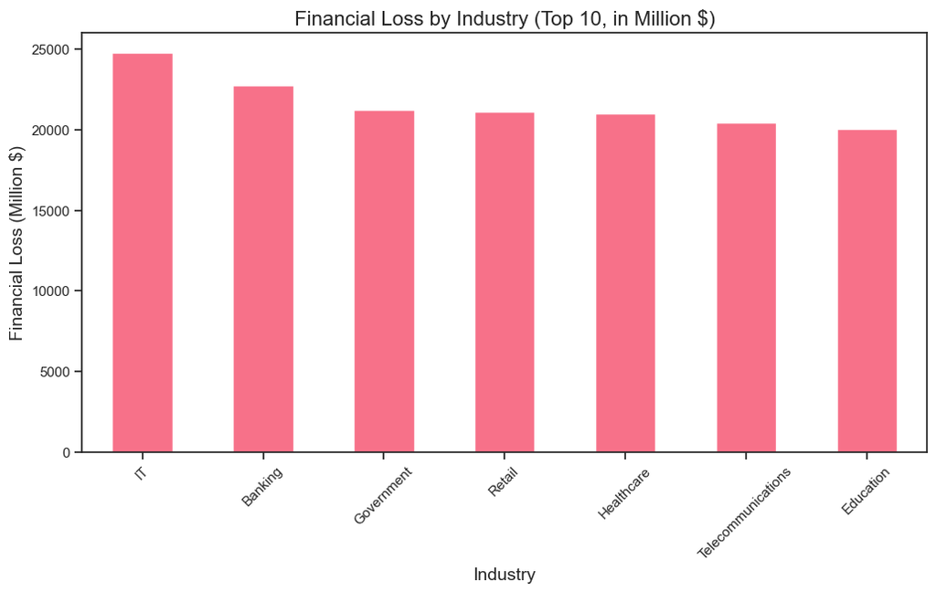

```python
# Financial loss by industry (top 10)
loss_by_industry = df.groupby('Target Industry')['Financial Loss (in Million $)'].sum().sort_values(ascending=False).head(10)
plt.figure(figsize=(12, 6))
loss_by_industry.plot(kind='bar')
plt.title('Financial Loss by Industry (Top 10, in Million $)', fontsize=16)
plt.xlabel('Industry', fontsize=14)
plt.ylabel('Financial Loss (Million $)', fontsize=14)
plt.xticks(rotation=45)
plt.show()
```

## Attack Source Analysis

Who's Behind the Attacks?

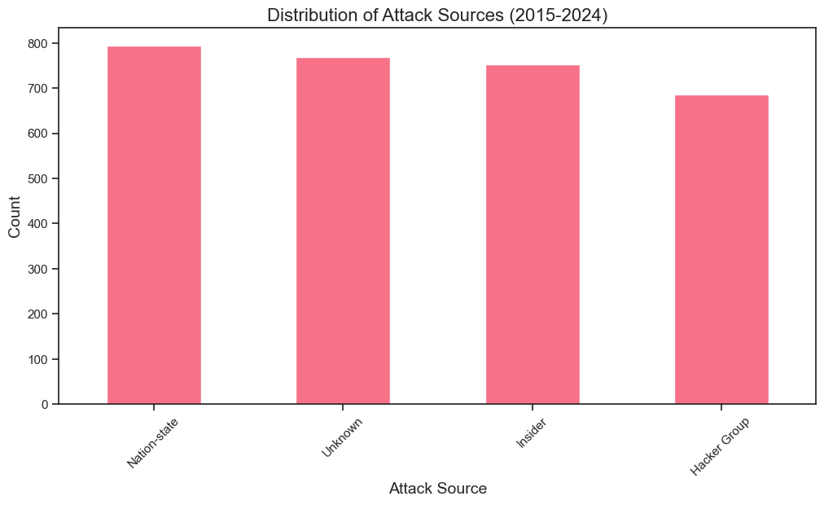

```python
# Attack sources
plt.figure(figsize=(12, 6))
source_counts = df['Attack Source'].value_counts()
source_counts.plot(kind='bar')
plt.title('Distribution of Attack Sources (2015-2024)', fontsize=16)
plt.xlabel('Attack Source', fontsize=14)
plt.ylabel('Count', fontsize=14)
plt.xticks(rotation=45)
plt.show()
```

Attack Sources by Country

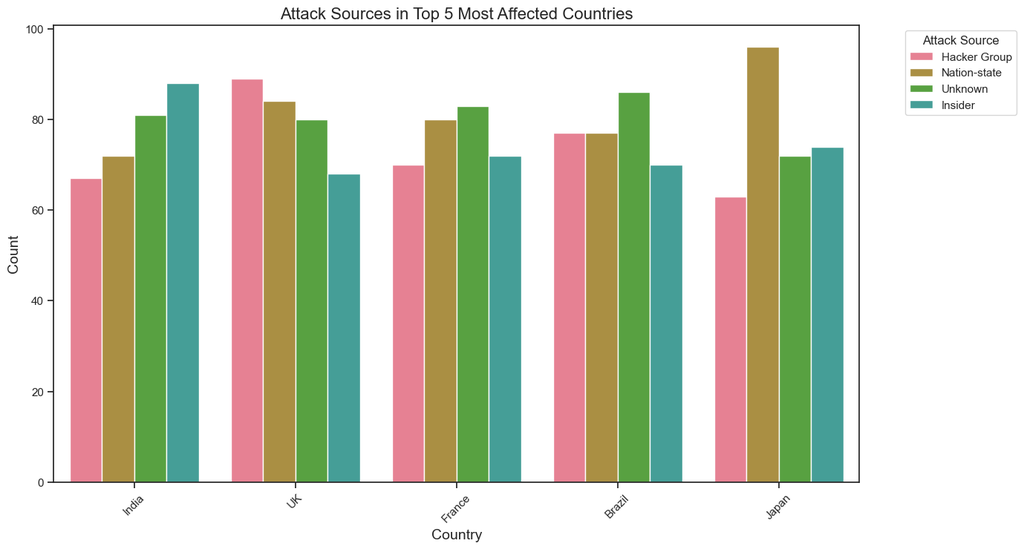

```python
# Attack sources by country (top 5 countries)
top_countries = df['Country'].value_counts().head(5).index
df_top = df[df['Country'].isin(top_countries)]

plt.figure(figsize=(14, 8))
sns.countplot(x='Country', hue='Attack Source', data=df_top)
plt.title('Attack Sources in Top 5 Most Affected Countries', fontsize=16)
plt.xlabel('Country', fontsize=14)
plt.ylabel('Count', fontsize=14)
plt.legend(title='Attack Source', bbox_to_anchor=(1.05, 1), loc='upper left')
plt.xticks(rotation=45)
plt.show()
```

## Security Vulnerabilities

Most Exploited Vulnerabilities

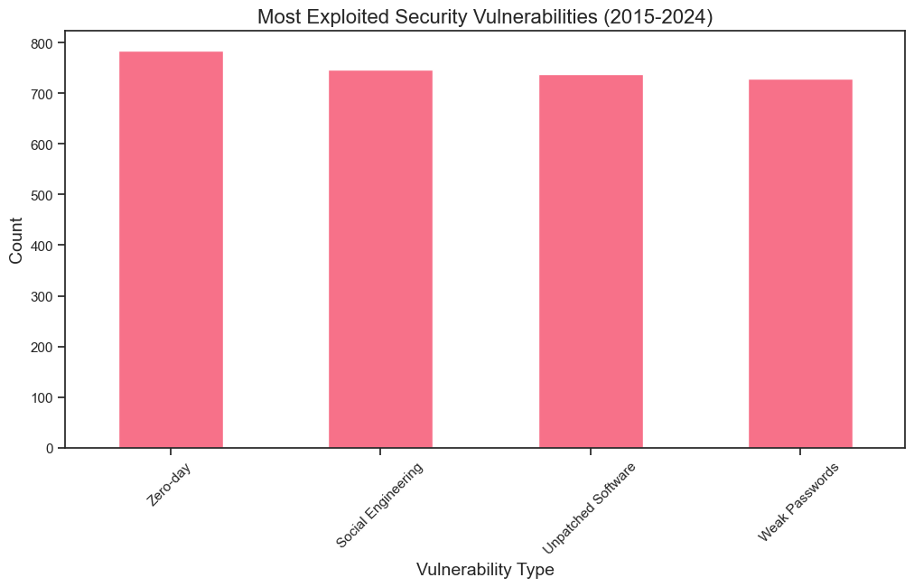

```python
# Security vulnerabilities
plt.figure(figsize=(12, 6))
vuln_counts = df['Security Vulnerability Type'].value_counts()
vuln_counts.plot(kind='bar')
plt.title('Most Exploited Security Vulnerabilities (2015-2024)', fontsize=16)
plt.xlabel('Vulnerability Type', fontsize=14)
plt.ylabel('Count', fontsize=14)
plt.xticks(rotation=45)
plt.show()
```

Vulnerabilities by Attack Type

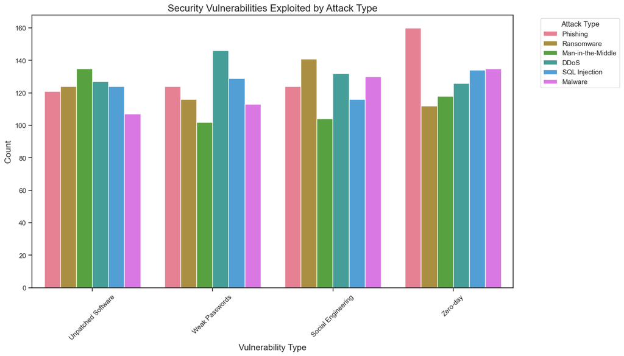

```python
# Vulnerabilities by attack type
plt.figure(figsize=(14, 8))
sns.countplot(x='Security Vulnerability Type', hue='Attack Type', data=df)
plt.title('Security Vulnerabilities Exploited by Attack Type', fontsize=16)
plt.xlabel('Vulnerability Type', fontsize=14)
plt.ylabel('Count', fontsize=14)
plt.legend(title='Attack Type', bbox_to_anchor=(1.05, 1), loc='upper left')
plt.xticks(rotation=45)
plt.show()
```

## Defense Mechanisms

Most Used Defense Mechanisms

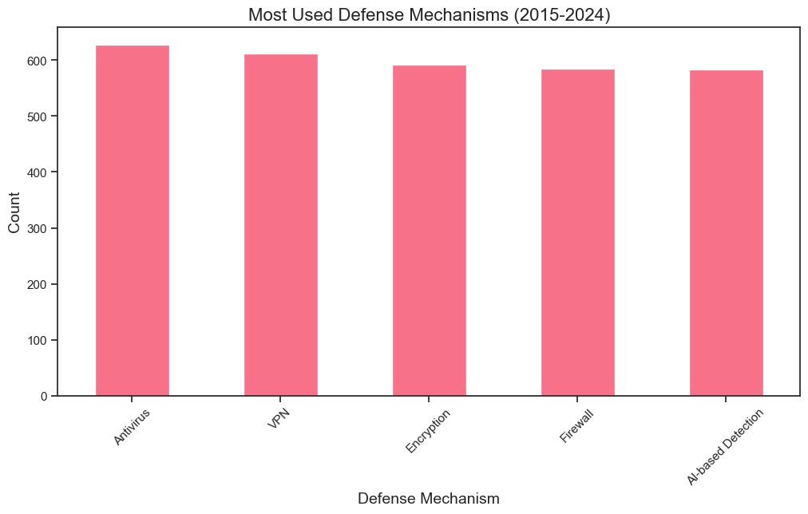

```python
# Defense mechanisms
plt.figure(figsize=(12, 6))
defense_counts = df['Defense Mechanism Used'].value_counts()
defense_counts.plot(kind='bar')
plt.title('Most Used Defense Mechanisms (2015-2024)', fontsize=16)
plt.xlabel('Defense Mechanism', fontsize=14)
plt.ylabel('Count', fontsize=14)
plt.xticks(rotation=45)
plt.show()
```

Defense Mechanisms vs. Attack Types

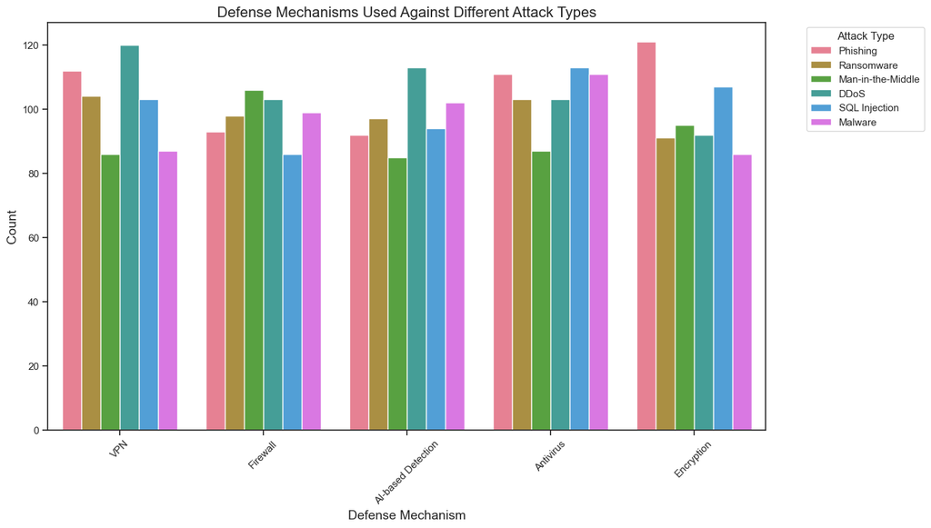

```python
# Defense mechanisms by attack type
plt.figure(figsize=(14, 8))
sns.countplot(x='Defense Mechanism Used', hue='Attack Type', data=df)
plt.title('Defense Mechanisms Used Against Different Attack Types', fontsize=16)
plt.xlabel('Defense Mechanism', fontsize=14)
plt.ylabel('Count', fontsize=14)
plt.legend(title='Attack Type', bbox_to_anchor=(1.05, 1), loc='upper left')
plt.xticks(rotation=45)
plt.show()
```

## Incident Resolution Time

Average Resolution Time by Attack Type

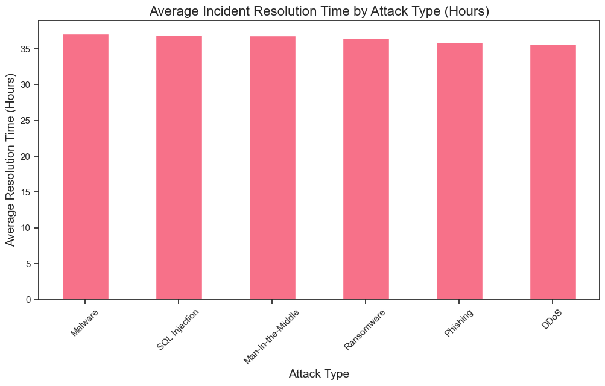

```python
# Resolution time by attack type
plt.figure(figsize=(12, 6))
resolution_time = df.groupby('Attack Type')['Incident Resolution Time (in Hours)'].mean().sort_values(ascending=False)
resolution_time.plot(kind='bar')
plt.title('Average Incident Resolution Time by Attack Type (Hours)', fontsize=16)
plt.xlabel('Attack Type', fontsize=14)
plt.ylabel('Average Resolution Time (Hours)', fontsize=14)
plt.xticks(rotation=45)
plt.show()
```

Resolution Time Trends Over Years

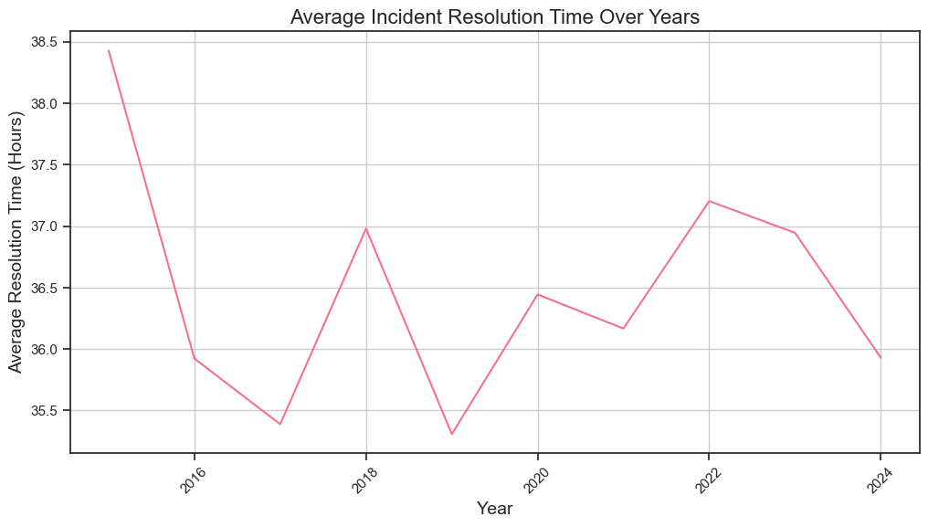

```python
# Resolution time trends
plt.figure(figsize=(12, 6))
df.groupby('Year')['Incident Resolution Time (in Hours)'].mean().plot()
plt.title('Average Incident Resolution Time Over Years', fontsize=16)
plt.xlabel('Year', fontsize=14)
plt.ylabel('Average Resolution Time (Hours)', fontsize=14)
plt.xticks(rotation=45)
plt.grid(True)
plt.show()
```

## Advanced Analysis

Correlation Matrix

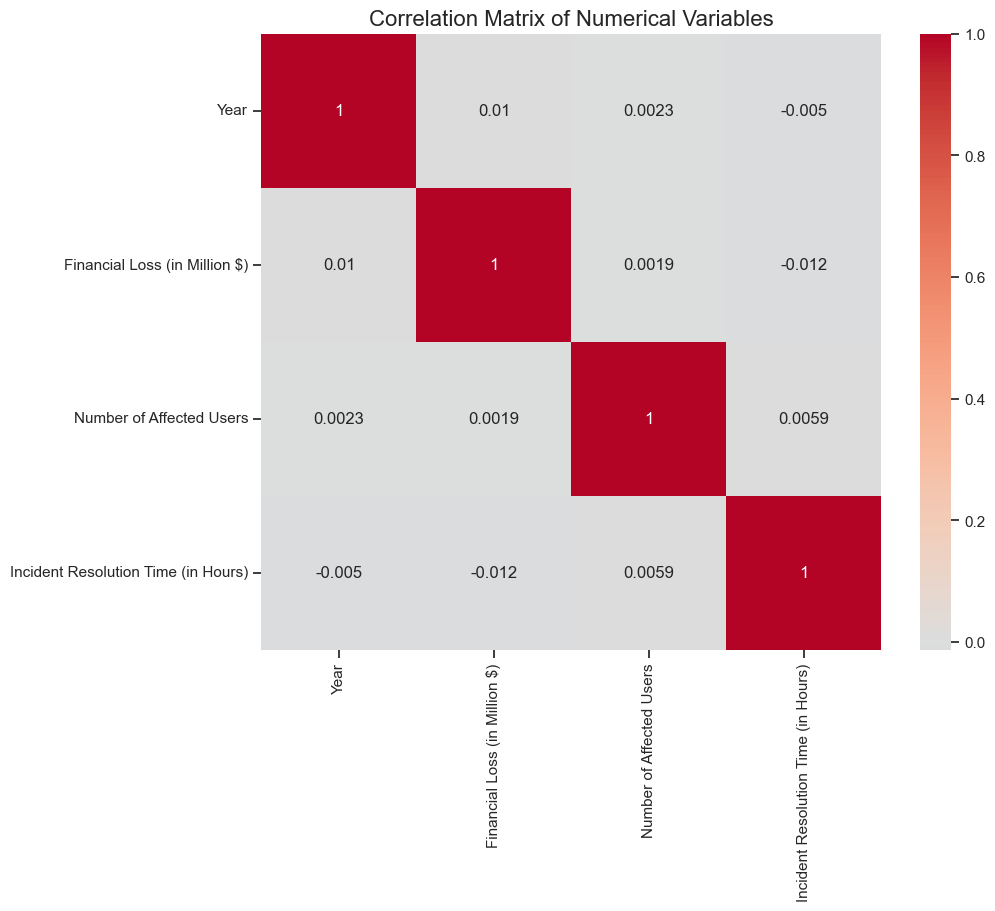

```python
# Create a numerical dataframe for correlation
num_df = df.select_dtypes(include=[np.number])

# Plot correlation matrix
plt.figure(figsize=(10, 8))
sns.heatmap(num_df.corr(), annot=True, cmap='coolwarm', center=0)
plt.title('Correlation Matrix of Numerical Variables', fontsize=16)
plt.show()
```

Financial Loss vs. Resolution Time

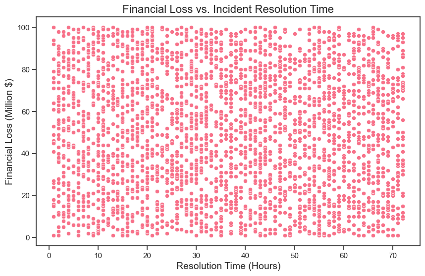

```python
# Financial loss vs resolution time
plt.figure(figsize=(10, 6))
sns.scatterplot(x='Incident Resolution Time (in Hours)', y='Financial Loss (in Million $)', data=df)
plt.title('Financial Loss vs. Incident Resolution Time', fontsize=16)
plt.xlabel('Resolution Time (Hours)', fontsize=14)
plt.ylabel('Financial Loss (Million $)', fontsize=14)
plt.show()
```

## Key Questions and Answers

Q1: Which country experienced the highest number of cyber attacks between 2015-2024?

```python
top_country = df['Country'].value_counts().idxmax()
top_country_count = df['Country'].value_counts().max()
print(f"A1: {top_country} experienced the highest number of cyber attacks with {top_country_count} incidents.")
```

```
A1: UK experienced the highest number of cyber attacks with 321 incidents.
```

Q2: What is the most common type of cyber attack?

```python
common_attack = df['Attack Type'].value_counts().idxmax()
common_attack_count = df['Attack Type'].value_counts().max()
print(f"A2: The most common attack type is {common_attack} with {common_attack_count} incidents.")
```

```
A2: The most common attack type is DDoS with 531 incidents.
```

Q3: Which industry suffered the highest financial losses due to cyber attacks?

```python
industry_max_loss = df.groupby('Target Industry')['Financial Loss (in Million $)'].sum().idxmax()
max_loss = df.groupby('Target Industry')['Financial Loss (in Million $)'].sum().max()
print(f"A3: The {industry_max_loss} industry suffered the highest financial losses totaling ${max_loss:.2f} million.")
```

```
A3: The IT industry suffered the highest financial losses totaling $24805.00 million.
```

Q4: What is the most exploited security vulnerability?

```python
common_vuln = df['Security Vulnerability Type'].value_counts().idxmax()
common_vuln_count = df['Security Vulnerability Type'].value_counts().max()
print(f"A4: The most exploited vulnerability is '{common_vuln}' with {common_vuln_count} incidents.")
```

```
A4: The most exploited vulnerability is 'Zero-day' with 785 incidents.
```

Q5: Which attack type takes the longest to resolve on average?

```python
longest_resolution = df.groupby('Attack Type')['Incident Resolution Time (in Hours)'].mean().idxmax()
avg_time = df.groupby('Attack Type')['Incident Resolution Time (in Hours)'].mean().max()
print(f" {longest_resolution} attacks take the longest to resolve with an average of {avg_time:.1f} hours.")
```

```
 Malware attacks take the longest to resolve with an average of 37.1 hours.
```

Q6: Has the average resolution time for incidents improved over the years?

```python
resolution_trend = df.groupby('Year')['Incident Resolution Time (in Hours)'].mean()
if resolution_trend.iloc[-1] < resolution_trend.iloc[0]:
    trend = "improved"
else:
    trend = "not improved" if resolution_trend.iloc[-1] == resolution_trend.iloc[0] else "worsened"
print(f"A6: The average resolution time has {trend} from {resolution_trend.iloc[0]:.1f} hours in {resolution_trend.index[0]} to {resolution_trend.iloc[-1]:.1f} hours in {resolution_trend.index[-1]}.")
```

```
A6: The average resolution time has improved from 38.4 hours in 2015 to 35.9 hours in 2024.
```

Q7: What is the most common defense mechanism used against cyber attacks?

```python
common_defense = df['Defense Mechanism Used'].value_counts().idxmax()
common_defense_count = df['Defense Mechanism Used'].value_counts().max()
print(f" The most common defense mechanism used is {common_defense} with {common_defense_count} incidents.")
```

```
 The most common defense mechanism used is Antivirus with 628 incidents.
```

Q8: Which attack source is most responsible for cyber attacks?

```python
common_source = df['Attack Source'].value_counts().idxmax()
common_source_count = df['Attack Source'].value_counts().max()
print(f"The most common attack source is {common_source} responsible for {common_source_count} incidents.")
```

```
The most common attack source is Nation-state responsible for 794 incidents.
```

Q9: Is there a correlation between financial loss and number of affected users?

```python
correlation = df['Financial Loss (in Million $)'].corr(df['Number of Affected Users'])
print(f" The correlation between financial loss and number of affected users is {correlation:.2f}, indicating a {'positive' if correlation > 0 else 'negative' if correlation < 0 else 'no'} relationship.")
```

```
 The correlation between financial loss and number of affected users is 0.00, indicating a positive relationship.
```

Q10: How has the distribution of attack types changed over the years?

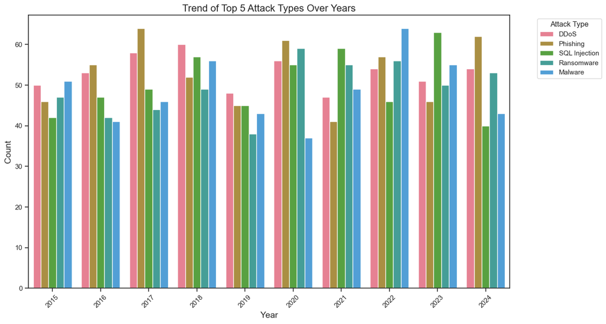

```
 The visualization above shows how the distribution of top 5 attack types has changed over the years.
```

```python
# Get top 5 attack types
top_attacks = df['Attack Type'].value_counts().head(5).index

# Filter data for top attacks
df_top_attacks = df[df['Attack Type'].isin(top_attacks)]

# Plot
plt.figure(figsize=(14, 8))
sns.countplot(x='Year', hue='Attack Type', data=df_top_attacks, hue_order=top_attacks)
plt.title('Trend of Top 5 Attack Types Over Years', fontsize=16)
plt.xlabel('Year', fontsize=14)
plt.ylabel('Count', fontsize=14)
plt.legend(title='Attack Type', bbox_to_anchor=(1.05, 1), loc='upper left')
plt.xticks(rotation=45)
plt.show()

print(" The visualization above shows how the distribution of top 5 attack types has changed over the years.")
```

## Conclusion

This analysis provides comprehensive insights into global cybersecurity threats from 2015 to 2024. Key findings include:

The most targeted countries and industries

The most common attack types and their financial impacts

Trends in vulnerabilities and defense mechanisms

Changes in incident resolution times

Relationships between different variables

The visualizations help identify patterns and trends that can inform cybersecurity strategies and resource allocation for different industries and regions.

```python
import nbformat
from nbconvert import HTMLExporter

# Load the Jupyter notebook (.ipynb) file
with open('Cybersecurity_Threats_Analysis.ipynb', 'r') as f:
    notebook_content = nbformat.read(f, as_version=4)

# Initialize the HTMLExporter
html_exporter = HTMLExporter()

# Convert the notebook to HTML format
html_data, resources = html_exporter.from_notebook_node(notebook_content)

# Save the HTML output to a new HTML file
with open('Cybersecurity_Threats_Analysis.html', 'w') as f:
    f.write(html_data)

print("Notebook has been converted to HTML and saved as output_notebook.html.")
```

[output not shown]